# Seitenverzeichnis

Verzeichnis

Veröffentlichungsdatum

6. Mai 2026

Geändert

17. September 2026

Vorschaubild

Titel

Veröffentlichung

Änderung

Schlagwörter

Allgmeine Hinweise zur Website und zum Programm (Im Aufbau)

2026-05-20

2026-09-23

Methodik

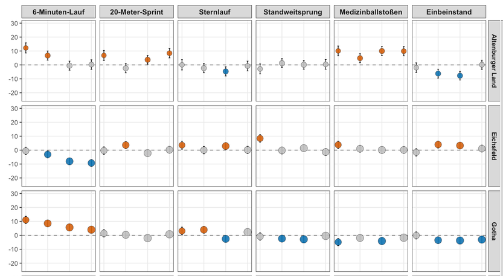

Randbereichs-Trends motorischer Testleistungen nach Kreis und Erhebungswelle

2026-09-14

2026-09-23

zeitlich, räumlich, Kreisebene, 20-Meter-Sprint, 6-Minuten-Lauf, Standweitsprung, Einbeinstand, Medizinballstoßen, Sternlauf

[figure not shown]

Wozu BeKiGeKi?

2024-06-17

2026-09-21

Einleitung

[figure not shown]

Zeitlicher Verlauf Teilnehmerzahlen Sport-AG und Vereinsmitgliedschaft

2024-07-09

2026-09-18

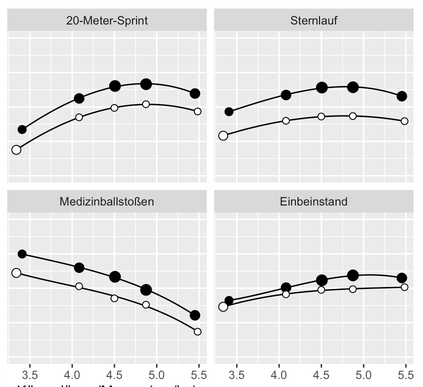

Mittlere Testergebnisse: Zusammenhänge mit Konstitution, Sportverein und Geschlecht

2024-06-12

2026-09-18

[figure not shown]

Archiv Vortragsfolien

2024-03-18

2026-09-18

[figure not shown]

Trägerschaft

2024-07-04

2026-09-18

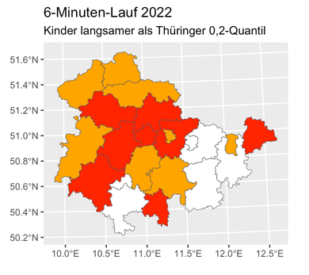

Laufausdauer, Konstitution und Kinderarmut 2022

2024-07-15

2026-09-18

Kreisebene, externe Daten

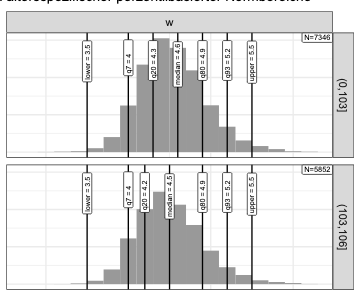

Referenzperzentile

2024-08-29

2026-09-18

Archiv, Landesebene, Verein, Sport-AG, Geschlecht, Alter

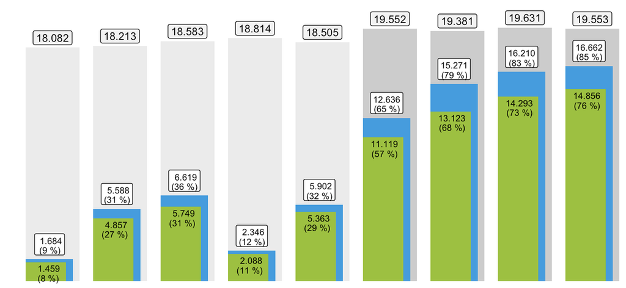

Teilnehmerzahlen

2023-03-09

2026-09-18

Landesebene, Teilnehmerzahl, zeitlich

Glossar (im Aufbau)

2026-05-20

2026-09-17

Verzeichnis

[figure not shown]

Archiv Erhebungswelle 2025/2026

2026-05-19

2026-09-17

Archiv, Landesebene, Kreisebene, Schulebene, Verein, Sport-AG, Geschlecht

Handout-Bibliothek

2026-08-07

2026-09-17

Index

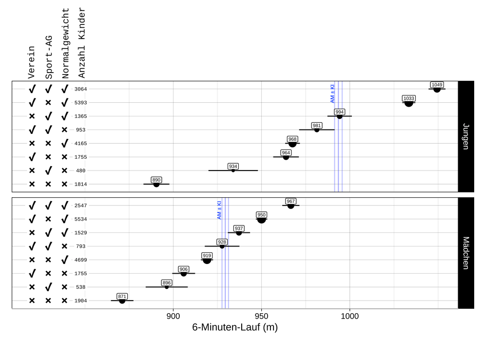

Mittlere motorische Testleistungen

2024-06-26

2026-09-17

Landesebene, Verein, Sport-AG, Konstitution, Geschlecht

Verzeichnis der Datenquellen

2026-08-21

2026-09-17

Verzeichnis

[figure not shown]

Version für Druck im Schuljahr 2023/2024

2024-03-18

2026-09-17

Archiv, Kreisebene, Schulebene, Druck

[figure not shown]

Version für Druck im Schuljahr 2024/2025

2025-02-19

2026-09-17

Archiv, Landesebene, Kreisebene, Schulebene, Verein, Sport-AG, Geschlecht

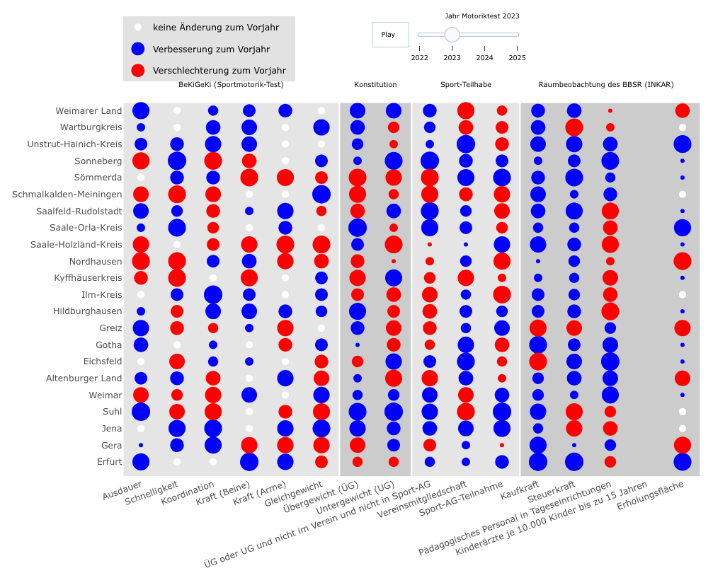

Thüringer Rangplatzanalyse (Kreisebene)

2024-08-10

2026-09-17

Kreisebene, externe Daten, Konstitution, Sport-AG, Verein, zeitlich, räumlich

[figure not shown]

Schuljahre 2017-2022

2023-04-24

2026-09-17

Archiv, 2022, Schulebene, Kreisebene

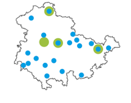

Sport-Veranstaltungen

2023-04-25

2026-09-17

Landesebene